# Apuntes - Estadística No Paramétrica

*Víctor E. Acaro B.*

*Abril, 18 del 2024*

# 1 Probabilidad

## 1.1 Espacio muestral

**Definición** Sea *E* un experimento no determinístico, entonces $\Omega$ es el conjunto de todos los posibles resultados de *E*.

**Ejemplos:**

1. Experimento: lanzar una moneda
   $$\Omega = \{cara, sello\}$$
2. Experimento: lanzar un dado
   $$\Omega = \{1,2,3,4,5,6\}$$
3. Experimento: una rifa
   $$\Omega = \{\textit{númeroos de los boletos vendidos}\}$$

## 1.2 Conjunto Potencia o Partes de $\Omega$

$$\mathscr{P}(\Omega)=2^{\Omega}=\{A\mid A\subseteq \Omega\}$$

**Ejemplos:**

1. Experimento: lanzar una moneda
   $$\mathscr{P}(\Omega)=2^{\Omega}=\{ \emptyset,\{cara\},\{sello\},\{cara, sello\} \}$$

$$Cardinalidad \,\, \mathscr(\mathscr{P}(\Omega))=4$$

2. Experimento: lanzar un dado
   $$\mathscr{P}(\Omega)=2^{\Omega}=\{ \emptyset,\{1\},\{2\},\{3\}, .... ,\Omega,\emptyset \}$$

$$Cardinalidad \,\, \mathscr(\mathscr{P}(\Omega))=64$$

## 1.3 Sigma Álgebra

**Definición** Sea $\Omega$ un conjunto fundamental de resultados de un experimento no determinístico específico, entonces,

$$\mathscr{P}(\Omega) \textit{es una} \,\, sigma - álgebra$$

que verifica las siguientes propiedades:

1. $\Omega \in \mathscr{P}(\Omega)$
2. $\forall \in \mathscr{P}(\Omega) \Rightarrow A^{c} \in \mathscr{P}(\Omega)$
3. $\forall A_1,A_2, \ldots , A_n \in \mathscr{P}(\Omega) \Rightarrow \bigcup A_i \in \mathscr{P}(\Omega)$

**Ejemplo:**

Sea $\mathscr{F}=\{ \Omega, \emptyset \}$ una familia de conjuntos. Probar que esta familia $\mathscr{F}$ es una $\textit{sigma-álgebra}$.

1. Se conoce que $\Omega \in \mathscr{F}$, por tanto, se cumple la primera propiedad.
2. $\Omega \in \mathscr{F} \Rightarrow \Omega^{c}= \emptyset \in \mathscr{F}$ y $\emptyset \in \mathscr{F} \Rightarrow \emptyset^{c} = \Omega \in \mathscr{F}$, por tanto, se cumple la segunda propiedad.
3. $\Omega \cup \emptyset = \Omega \in \mathscr{F}$

## 1.4 Evento

**Definición** Sea $\Omega$ un conjunto fundamental de resultados de un experimento no determinístico determinado y $\mathscr{P}(\Omega)$ un $\textit{sigma-álgebra}$, entonces,
$$\forall A \in \mathscr{P}(\Omega)$$
es un Evento.

### 1.4.1 Preguntas

| Pregunta | Respuesta |
| --- | --- |
| ¿Qué es un $\textit{sigma-álgebra}$? | Familia de subconjuntos de $\Omega$ |
| ¿Qué se verifica al tratarse de un $\textit{sigma-álgebra}$? | Se verifica las operaciones de conjuntos. |
| ¿Qué es un Evento? | Cualquier subconjunto de $\Omega$, es un Evento. Es decir, todo subconjunto del conjunto fundamental de resultados, es un Evento |

## 1.5 Álgebra de Eventos

1. $\forall A,B \in \mathscr{P}(\Omega)$, es decir, $A \cup B = \{ x \mid x \in A \vee x \in B\}$
2. $\forall A,B \in \mathscr{P}(\Omega)$, es decir, $A \cap B = \{ x \mid x \in A \wedge x \in B\}$
3. $\forall A,B \in \mathscr{P}(\Omega)$, es decir, $A - B = \{ x \mid x \in A \wedge x \notin B\}$
4. $\forall A \in \mathscr{P}(\Omega)$, es decir, $A^{c} = \{ x \mid x \notin A \wedge x \in \Omega\}$
5. $\forall A,B \in \mathscr{P}(\Omega)$, es decir, $A \triangle B = (A-B) \cup (B-A) \equiv A \triangle B = (A \cup B) - (A \cap B)$
6. $\forall A \in \mathscr{P}(\Omega)$, es decir, $(A \cup B)=A^c \cap B^c$

## 1.6 Espacio Medible

**Definición** Sea $\Omega$ un conjunto fundamental de resultados de un experimento no terminístico y $\mathscr{P}(\Omega)$, entonces, la dupla
$$(\Omega, \mathscr{P}(\Omega))$$
es un Espacio Medible. Donde: $\Omega$ es el Conjunto fundamental de resultados y $\mathscr{P}(\Omega) \,\, \textit{sigma-álgebra}$

## 1.7 Función de Probabilidad

**Definición** Sea $(\Omega, \mathscr{P}(\Omega))$ un espacio medible, etnonces, la función definida por
$$\mathbf{P}: \mathscr{P}(\Omega) \rightarrow [0,1]$$
$$\,\,\,\,\,\,\,\,\,\,\,\,\,\,\,\,\,\, A \mapsto \mathbf{P}(A)$$

## 1.8 Propiedades que cumple la Función de Probabilidad - Axiomas de Kolmogorov

1. $\mathscr{P}(\Omega)=1$, es decir, $\Omega$ evento seguro
2. $\mathscr{P}(\emptyset)=0$, es decir, $\emptyset$ evento imposible
3. $\mathscr{P}(A^c)=1-\mathscr{P}(A)$
4. $\forall A,B \in \mathscr{P}(\Omega)$
   $$\mathbf{P}(A \cup B)=\mathbf{P}(A)+\mathbf{P}(B)$$
   si y solo si, $A$ y $B$ son independientes,
   $$\mathbf{P}(A \cup B)=\mathbf{P}(A)+\mathbf{P}(B)-\mathbf{P}(A \cap B)$$
   si y solo si, $A$ y $B$ no son independientes, o dependientes.

**Ejercicio:**

Sea $A,B \in \mathscr{P}(\Omega)$ donde $A = \emptyset$ y $B \neq \emptyset$. Calcular la probabilidad de $A \cap B$.

Tenemos:

$$A \cap B = \emptyset \cap B = \emptyset$$

finalmente,

$$\mathbf{P}(A \cap B) = \mathbf{P}(\emptyset) = 0$$

## 1.9 Espacio de Probabilidad

**Definición** Sea $(\Omega, \mathscr{P}(\Omega))$ un espacio medible y $\mathbf{P}$ la función de probabilidad definida en este espacio, entonces, la tripleta

$$(\Omega, \mathscr{P}(\Omega), \mathbf{P})$$

se le llama, Espacio de Probabilidad.

**Ejemplo:**

- Experimento: lanzar una moneda

$$\Omega = \{cara, sello \}$$

$$\mathscr{P}(\Omega) = \{\Omega, \emptyset, \{cara\}, \{sello\} \}$$

siendo,

$$(\Omega, \mathscr{P}(\Omega), \mathbf{P})$$

un espacio de probabilidad,

$$\mathbf{P}: \mathscr{P}(\Omega) \rightarrow [0,1]$$

por Axiomas de Kolmogorov,

$$\,\,\,\,\,\,\,\,\,\,\,\,\,\,\,\,\,\, \Omega \mapsto \mathbf{P}(\Omega) = 1$$
$$\,\,\,\,\,\,\,\,\,\,\,\,\,\,\,\,\,\, \emptyset \mapsto \mathbf{P}(\emptyset) = 0$$
$$\,\,\,\,\,\,\,\,\,\,\,\,\,\,\,\,\,\, \{cara\} \mapsto \mathbf{P}(\{cara\}) = \frac{1}{2}$$
$$\,\,\,\,\,\,\,\,\,\,\,\,\,\,\,\,\,\, \{sello\} \mapsto \mathbf{P}(\{sello\}) = \frac{1}{2}$$

## 1.10 Teorema de Equiprobabilidad

**Definición** Sea $(\Omega, \mathscr{P}(\Omega), \mathbf{P})$ un espacio de probabilidad donde $\Omega = \{x_1,x_2, \dotsc , x_n\}$ y $\mathbf{P}(\{x_1\})=\mathbf{P}(\{x_2\})= \dotsc =\mathbf{P}(\{x_n\})$, entonces,$\forall i = \overline{i,n} \mid \mathbf{P}(\{x_i\}) = \frac{1}{n}$.

$\underline{Demostración:}$

tenemos, $\Omega = \{x_1,x_2, \dotsc , x_n\}, \mathscr{C}(\Omega) = n$ y $\mathscr{P}(\Omega) = \mathscr{P}(\{x_1,x_2, \dotsc , x_n\})$

mediante,
$$\mathscr{P}(\Omega) = \mathscr{P}(\{x_1,x_2, \dotsc , x_n\}) \equiv 1 = \mathscr{P}(\{x_1\}\cup\{x_2\}\cup \dotsc \cup \{x_n\})$$

como, $\{x_1,x_2, \dotsc , x_n\}$ son independientes entre sí,

$$\mathscr{P}(\Omega) = \mathscr{P}(\{x_1,x_2, \dotsc , x_n\}) \equiv 1 = \mathscr{P}(\{x_1\} + \mathscr{P}(\{x_2\} + \dotsc + \mathscr{P}(\{x_n\}$$

$$\mathscr{P}(\Omega) = \mathscr{P}(\{x_1,x_2, \dotsc , x_n\}) \equiv \forall i = \overline{i,n} 1 : n \mathscr{P}(\{x_n\}$$

$$\mathscr{P}(\Omega) = \mathscr{P}(\{x_1,x_2, \dotsc , x_n\}) \equiv \mathscr{P}(\{x_i\})=\frac{1}{n}$$

## 1.11 Proposición

Sea $(\Omega, \mathscr{P}(\Omega), \mathbf{P})$ un Espacio de Probabilidad, entonces,
$$\forall A \in \mathscr{P}(\Omega) \mid A=\{x_1,x_2, \ldots, x_k\} \,\textit{y}\,\, \Omega=\{x_1,x_2, \ldots, x_n\}$$
donde, $k \leq n$, se tiene que
$$\mathbf{P}(A)=\frac{\mathscr{C}(A)}{\mathscr{C}(\Omega)}=\frac{k}{n}$$

**Ejercicio:** Ejemplo: lanzar dos monedas. Calcular, la probabilidad de tener al menos una cara. $\underline{Tenemos:}$
$$\Omega=\{(cara, cara)(sello, sello)(cara, sello)(sello, cara)\}$$
$$\mathscr{P}(\Omega)=\{\Omega, \emptyset, \{(cara, cara)(sello, cara)\},\{(cara, cara)\}, \ldots\}$$
$$\mathscr{C}(\Omega)=2^4=16$$
$\underline{Ahora}$
$$A=\{\textit{Obtener al menos una cara}\}$$
$$A=\{(cara, cara)(cara, sello)\}$$
$$\mathscr{C}(A)=2^2=4$$
$\underline{Finalmente,}$
$$\mathbf{P}(A)=\frac{\mathscr{C}(A)}{\mathscr{C}(\Omega)}=\frac{2}{4}=\frac{1}{2}$$

## 1.12 Probabilidad Condicional

**Definición** Sea $(\Omega, \mathscr{P}(\Omega), \mathbf{P})$ un Espacio de Probabilidad, entonces,
$$\forall A,B \in \mathscr{P}(\Omega): \mathbf{P}(A\mid B)=\frac{\mathbf{P}(A\cap B)}{\mathbf{P}(B)}$$
donde $\mathbf{P}(B)\neq 0$
$$\,\, \mathbf{P}(B\mid A)=\frac{\mathbf{P}(A\cap B)}{\mathbf{P}(A)}$$
donde $\mathbf{P}(A)\neq 0$

*Al tener Probabilidad Condicionada, nos podemos preguntar:* **¿Cuál es la Probabilidad de que exista algo de A en B?**

**Ejercicio:** Sea $(\Omega, \mathscr{P}(\Omega), \mathbf{P})$ un Espacio de Probabilidad, entonces. Si $A = \emptyset, B\neq \emptyset$. Calcular la probabilidad conjunta de $\mathbf{P}(A\mid B)$ y $\mathbf{P}(B\mid A)$.
$$\mathbf{P}(A\mid B)=\frac{\mathbf{P}(A\cap B)}{\mathbf{P}(B)}=\frac{\mathbf{P}(\emptyset)}{\mathbf{P}(B)}=0$$
$$\mathbf{P}(B\mid A)=\frac{\mathbf{P}(A\cap B)}{\mathbf{P}(A)}=\frac{\mathbf{P}(\emptyset)}{\mathbf{P}(\emptyset)}=\frac{0}{0}= \textbf{Ind.}$$

## 1.13 Independiencia de Eventos

**Definición** Sea $(\Omega, \mathscr{P}(\Omega), \mathbf{P})$ un Espacio de Probabilidad. Donde, si $\mathbf{P}(A\cap B)=\mathbf{P}(A)\cdot \mathbf{P}(B)$, entonces, $A$ y $B$ son eventos independientes.

## 1.14 Probabilidad Total

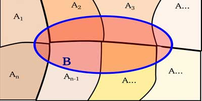

Teorema Probabilidad Total

**Definición** Sea $(\Omega, \mathscr{P}(\Omega), \mathbf{P})$, tal que, $\Omega = \bigcup A_i \,\,$; $\,\forall A_i,A_j: A_i \cap A_j=\emptyset\,\, y\,\, i \neq j$. Probemos, $\mathbf{P}(B)$. $\underline{Tomemos:}$
$$\mathbf{P}(B)=\mathbf{P}((B\cap A_1)\cup(B\cap A_2)\cup \cdots \cup (B\cap A_n))$$
como, sabemos que los eventos $\forall A_i \mid i:\overline{i,n}$ son independientes,
$$\mathbf{P}(B)=\mathbf{P}(B\cap A_1)+\mathbf{P}(B\cap A_2)+ \cdots + \mathbf{P}(B\cap A_n)$$
tengamos en cuenta lo siguiente,
$$\mathbf{P}(B\mid A_1)=\frac{\mathbf{P}(B\cap A_1)}{\mathbf{P}(A_1)}$$

$$\mathbf{P}(B\mid A_2)=\frac{\mathbf{P}(B\cap A_2)}{\mathbf{P}(A_2)}$$

$$\vdots$$

$$\mathbf{P}(B\mid A_n)=\frac{\mathbf{P}(B\cap A_n)}{\mathbf{P}(A_n)}$$
por tanto,
$$\mathbf{P}(B)=\mathbf{P}(B\mid A_1)\cdot \mathbf{P}(A_1)+\mathbf{P}(B\mid A_2) \cdot \mathbf{P}(A_2)+ \cdots +\mathbf{P}(B\mid A_n)\cdot \mathbf{P} (A_n)$$
Finalmente,
$$\mathbf{P}(B)=\sum_{i=1}^{n}{\mathbf{P}(B\mid A_i) \cdot \mathbf{P}(A_i)}$$

**Ejemplo:** Experimento, al azar un estudiante de séptimo semestre paralelo 1. Calcular la Probabilidad de que es estudiante viva en el Sur de la ciudad. Sabemos que, estudiantes hombres son 7 y mujeres 8. Además, sabemos que el númeroo de hombres que vive en el Sur es de 3 y el númeroo de muejeres que vive en el Sur es 2. Consideremos el Evento $B=\{\textit{Estudiante que vive en el Sur de la ciudad}\}$.

$\underline{Tenemos:}$

$$\mathbf{P}=\sum_{i=1}^{2}{\mathbf{P}(B \mid A_i)\cdot \mathbf{P}(A_i)}$$
es decir,
$$\mathbf{P}=\mathbf{P}(B \mid H)\cdot \mathbf{P}(H)+\mathbf{P}(B \mid M)\cdot \mathbf{P}(M)$$
recordemos que, $\mathbf{P}(B \mid H)$ es la probabilidad del Evento B dado que sea hombre, sino también, la probabilidad de que exista una persona que viva en el Sur y este debe ser hombre.
$$\mathbf{P}=\frac{3}{7}\cdot \frac{7}{15}+\frac{2}{8}\cdot \frac{8}{15}$$

### 1.14.1 Teorema de Bayes

Usemos la gráfica anterior.

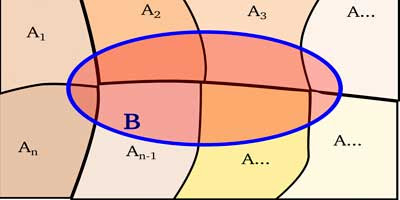

Teorema Probabilidad Total

Ahora, para conocer a Bayes. Se nos pide hallar $\mathbf{P}(A_j\mid B)$ donde $i \neq j$. Y recordemos que los Eventos son independientes.

$\underline{\textit{Samemos que:}}$
$$\mathbf{P}(A_j\mid B)=\frac{\mathbf{P}(A_{j}\,\cap B)}{\mathbf{P}(B)}$$
y de Probabilidad Total, tenemos
$$\mathbf{P}(A_j\mid B)=\frac{\mathbf{P}(A_{j}\cap B)}{\sum_{i=1}^{n}{\mathbf{P}(B \mid A_i)\cdot \mathbf{P}(A_i)}}$$
finalmente, junto a $\mathbf{P}(B\mid A_j)=\frac{\mathbf{P}(A_{j}\,\cap B)}{\mathbf{P}(A_j)}$
$$\mathbf{P}(A_j\mid B)=\frac{\mathbf{P}(B\mid A_j)\cdot \mathbf{P}(A_j) }{\sum_{i=1}^{n}{\mathbf{P}(B \mid A_i)\cdot \mathbf{P}(A_i)}}$$

**Experimento:** Calcular la probabilidad de que al azar se obtenga a una estudiante que viva en el Sur de la ciudad. Recordemos el ejercicio anterior, $B=\{\textit{Estudiante que vive en el Sur de la ciudad}\}$.

$$\mathbf{P}(M\mid B)=\frac{\mathbf{P}(M\,\cap B)}{\mathbf{P}(B)}$$

$$\mathbf{P}(M\mid B)=\frac{\mathbf{P}(M\mid B)\cdot \mathbf{P}(M)}{\mathbf{P}(B)}$$

$$\mathbf{P}(M\mid B)=\frac{\frac{2}{8}\cdot\frac{8}{15}}{\frac{1}{3}}$$

$$\mathbf{P}(M\mid B)=\frac{2}{5}$$

## 1.15 Variables Aleatorias

**Definición** Sea $(\Omega, \mathscr{P}(\Omega), \mathbf{P})$ un Espacio de Probabilidad, entonces, la función definida por:
$$X: \Omega \rightarrow \mathbb{R}_x \subseteq \mathbb{R}$$
$$\,\,\,\,\,\,\,\,\,\,\,\,\,\,\,\,\,\, \omega \mapsto X(\omega)$$
es una Variable Aleatoria.
**Ejemplo**
Experimento: lanzar dos monedas
$\underline{Tenemos:}$
$$\Omega=\{(cara, cara)(sello, sello)(cara, sello)(sello, cara)\}$$
$$X: \textit{Mide el númeroo de caras}$$
recordemos que $X$, tiene una naturaleza, es lo que indica su variable: edad, peso, etc.
$$X: \Omega \rightarrow \mathbb{R}_x \subseteq \mathbb{R}$$
$$\,\,\,\,\,\,\,\,\,\,\,\,\,\,\,\,\,\, (cara, cara) \mapsto X((cara, cara)) = 2$$
$$\,\,\,\,\,\,\,\,\,\,\,\,\,\,\,\,\,\, (cara, sello) \mapsto X((cara, sello)) = 1$$
$$\,\,\,\,\,\,\,\,\,\,\,\,\,\,\,\,\,\, (sello, cara) \mapsto X((sello, cara)) = 1$$
$$\,\,\,\,\,\,\,\,\,\,\,\,\,\,\,\,\,\, (sello, sello) \mapsto X((sello, sello)) = 0$$

## 1.16 Ley de Probabilidades de una Variable Aleatoria

**Definición** Sea $(\Omega, \mathscr{P}(\Omega), \mathbf{P})$ un Espacio de Probabilidad y $X$ una Variable Aleatoria definida en este espacio, entonces, la función definida por
$$f: \mathbb{R}_x \rightarrow [0, 1]$$
$$\,\,\,\,\,\,\,\,\,\,\,\,\,\,\,\,\,\, x \mapsto f(x)$$
se le conoce como la Ley de Probabilidad de la Variable Aleatoria $X$.

### 1.16.1 Tipos de Variables Aleatorias

**Variable Aleatoria Discreta:** Si $\mathbb{R}_x$ es un conjunto finito o infinito NUMERABLE.  
**Variable Aleatoria Continua:** Si $\mathbb{R}_x$ es un conjunto finito o infinito NO NUMERABLE.

## 1.17 Propiedades de las Variables Aleatorias

Si $X$ es una *Variable Aleatoria Discreta*,

- $\sum_{i=1}^{n}{f(x_i)=1}$
- $0\leq f(x_i) \leq 1$

Si $X$ es una *Variable Aleatoria Continua*,

- $\int_{- \infty}^{\infty}{f(x)\, dx=1}$
- $0\leq f(x) \leq 1$

$\underline{\textit{Caso Discreto}}$
**Ejemplo**
Experimento: lanzar dos monedas
$\underline{Tenemos:}$
$$\Omega=\{(cara, cara)(sello, sello)(cara, sello)(sello, cara)\}$$
$$X: \textit{Mide el número de caras}$$

[output not shown]

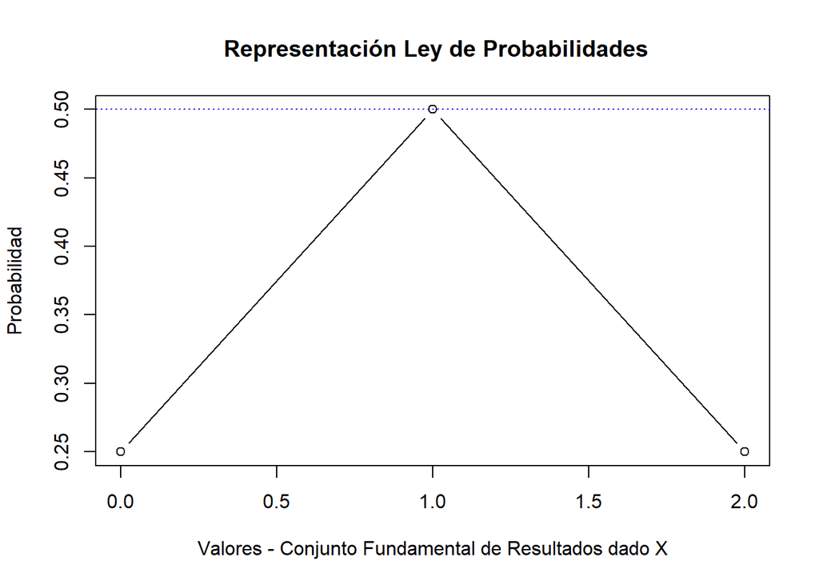

```r
# Generando los valores
x <- c(0, 1, 2)
y <- c(1/4,1/2,1/4)

# Generando la gráfica
plot(x, y, main = " Representación Ley de Probabilidades",
     xlab = "Valores - Conjunto Fundamental de Resultados dado X",
     ylab = "Probabilidad",
     type = "b", col = "black")
abline(h = 0.5, lty = 3, col = "blue")
```

$\underline{\textit{Caso Continuo}}$
**Ejemplo**
Sea $X$ una Variable Aleatoria Continua con la Ley de Probabilidad definida por,
$$f(x)= \begin{cases}
\frac{1}{b-a} & \text{si } x \in [a, b] \\
0 & \text{caso contrario }
\end{cases}$$
Probar que $f(x)$ es una Ley de Probabilidades. Para ello, basta con probar sus características. $\textit{Probemos entonces}$
$$\int_{-\infty}^{\infty}f(x) dx = 1$$
por tanto,
$$\int_{-\infty}^{\infty}f(x) dx = \int_{-\infty}^{a}f(x) dx+\int_{a}^{b}f(x) dx+\int_{b}^{\infty}f(x) dx$$
conocemos, por su definición que $\int_{-\infty}^{a}f(x) dx$ y $\int_{b}^{\infty}f(x) dx$ son cero, entonces,
$$\int_{-\infty}^{\infty}f(x) dx = \int_{a}^{b} \frac{1}{b-a} dx$$
$$\int_{-\infty}^{\infty}f(x) dx = \frac{1}{b-a} \cdot x \bigg|_{a}^{b}$$
$$\int_{-\infty}^{\infty}f(x) dx = \frac{b-a}{b-a}$$
$$\int_{-\infty}^{\infty}f(x) dx = 1$$

## 1.18 Varianza de la Variable Aleatoria X

**Definición** Sea $(\Omega, \mathscr{P}(\Omega), \mathbf{P})$ un espacio de probabilidad, entonces, la varianza de una variable aleatoria $X$, está dada por
$$V(X)=E(X-E(X))^2$$

### 1.18.1 Propiedades de la Varianza Aleatoria de X

Sea $X, Y$ variables aleatorias y $k \in \mathbb{R}$ una constante,

1. $V(k\cdot X)=k^2\cdot V(X)$
2. $V(X+Y)=V(X)+V(Y)+cov(X,Y)$, si $X, Y$ son dependientes $V(X+Y)=V(X)+V(Y)$, si $X, Y$ son independientes
3. $V(X)=E(X^2)-E^2(X)$

$\textit{Caso Discreto}$
**Ejemplo**
Experimento: lanzar dos monedas
$\underline{Tenemos:}$
$$\Omega=\{(cara, cara)(sello, sello)(cara, sello)(sello, cara)\}$$
$X:$ indica el número de caras

[output not shown]

luego,
$$V(X)=E(X^2)-E^2(X)$$
$$V(X)=\frac{3}{2}-1=\frac{1}{2}$$

## 1.19 Principales Distribuciones de Probabilidad con Variable Aleatoria Discreta

### 1.19.1 Distribución de Bernoulli

$$X \sim \textit{Bernoulli}(\mathcal{p})$$
cuando:

- $X:$ indica el éxito
- $\mathcal{p}=\mathbf{P}(éxito)$
- $1-\mathcal{p}= \mathbf{P}(fracaso)=\mathcal{q}$

| $\Omega$ | $X$ | $f(x)$ | $F(x)$ | $E(X)$ | $E(X^2)$ |
| --- | --- | --- | --- | --- | --- |
| Fracaso | 0 | $\mathbf{P}(X=0)=\mathcal{q}$ | $\mathcal{q}$ | $0 \cdot \mathcal{q}$ | $0^2 \cdot \mathcal{q}$ |
| Éxito | 1 | $\mathbf{P}(X=1)=\mathcal{p}$ | $\mathcal{p}+ \mathcal{q}$ | $1 \cdot \mathcal{p}$ | $1^2 \cdot \mathcal{p}$ |

$E(X)=\mathcal{p}$  
$V(X)=\mathcal{p}\cdot \mathcal{q}$

**Ejemplo**  
Experimento: calcular la probabilidad de que al seleccionar a un estudiante, este estudiante sea mujer.  
$\underline{\textit{Sabemos}}$ la probabilidad de las mujeres es $\frac{10}{15}$. Para obtener tal proporción, se pidió a un grupo de personas $(total=15)$ se enumeren y posteriormente, se clasificó en mujeres $(10)$ y hombres $(5)$.

|  | $X$ | $\mathbf{P}(X=x) = f(x)$ |
| --- | --- | --- |
| Mujeres | 1 | $p=\frac{10}{15}$ |
| Hombres | 0 | $q=\frac{5}{15}$ |

### 1.19.2 Distribución Binomial

$$X \sim \mathbf{B}(n, p)$$
Donde:

- $X:$ indica el número de éxitos al realizar n-veces el experimento.
- $p:$ probabilidad de éxito (debe determinarse).

$\textit{Demostración:}$ partamos, que Binomial se deduce de Bernoulli, entonces realizaremos n-veces el experimento con sus respectivos éxitos $E$ y fracasos $F$,
$$\mathbf{P}(E\cdot E\cdot F \ldots F\cdot F\cdot E) = \mathbf{P}(E) \cdot \mathbf{P}(E) \ldots \mathbf{P}(F) \cdot \mathbf{P}(E)$$
$$\mathbf{P}(X=k) = p\cdot p \ldots q \cdot q = p^k \cdot q^{n-k}$$
finalmente,
$$\mathbf{P}(X=k)= \binom{n}{k}\, p^k \cdot q^{n-k} = f(k)$$

Siguiendo el cálculo de la Esperanza Matemérica y Varianza, obtenemos:  
$E(X)= n \cdot p$  
$V(X)=n\cdot p \cdot q$

**Ejercicio**  
Considere lo siguiente:  
la proporción de mujeres en una aula de clases es $\frac{10}{15}$ y la variable aleatoria sigue una distribución de probabilidad $X \sim \mathbf{B}(n,p)$. En base a los datos proporcionados. ¿Cuál es la probabilidad de tener en los cinco estudiantes seleccionados dos de los seleecionados sean mujeres?.  
Recordemos, que la variable aleatoria $X \sim \mathbf{B}(n,p)$, entonces

$\mathbf{P}(X=x)= \binom{n}{x} \, p^{x} \cdot q^{n-k}$  
$\mathbf{P}(X=2)= \binom{5}{2} \, \left( \frac{10}{15} \rigth)^{x} \cdot \left( 1- \frac{10}{15} \right)^{n-k}$  
$\mathbf{P}(X=2)= \left(0,16 \right)$  
Calculemos el valor más probable de obtener (Esperanza Matemática),  
$\mathbf{B}(X)= n \cdot p = 5 \cdot \frac{10}{15} = 3,33$

```r
# Cálculo de probabilidad, con función de R
  # Datos
    n <- 5
    p <- 10/15
    x <- 2

cat( "El valor de la probabilidad es: ",dbinom(x, n, p))
```

```
## El valor de la probabilidad es:  0.1646091
```

```r
cat("La Esperanza Matemática es:", n*p)
```

```
## La Esperanza Matemática es: 3.333333
```

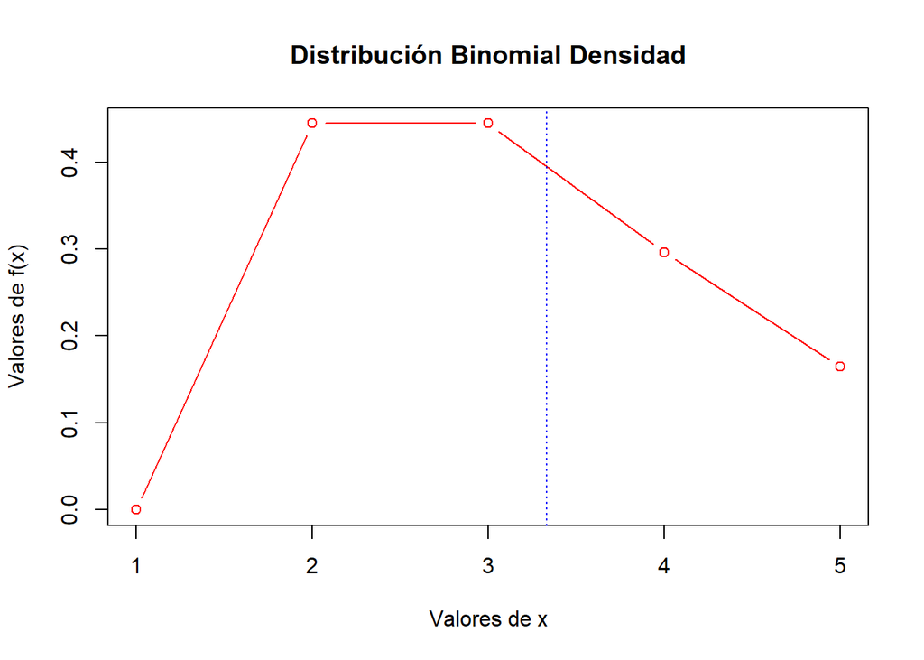

```r
# Gráfica de Distribución Binomial Densidad
plot(1:n, dbinom(x, 1:n, p), main = "Distribución Binomial Densidad",
     xlab = "Valores de x", ylab = "Valores de f(x)",
     type = "b", col = "red")
abline(v = n*p, lty = 3, col = "blue")
```

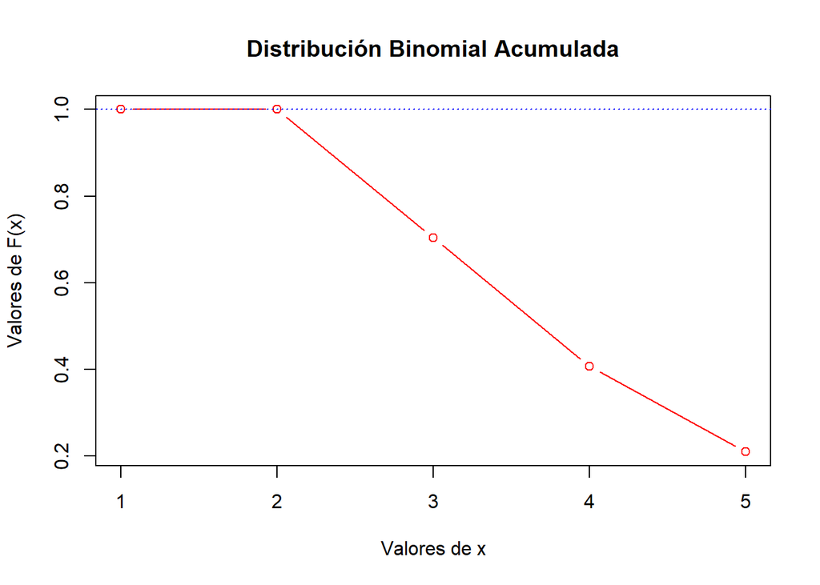

```r
# Gráfica de Distribución Binomial Acumulada
plot(1:n, pbinom(x, 1:n, p), main = "Distribución Binomial Acumulada",
     xlab = "Valores de x", ylab = "Valores de F(x)",
     type = "b", col = "red")
abline(h = 1, lty = 3, col = "blue")
```

### 1.19.3 Distribución Geométrica

$$X \sim \mathbf{G}(p)$$
Donde:

- $X:$ indica el número de veces que hay que realizar el experiemnto, hasta obtener el primer éxito.
- $p:$ probabilidad de éxito.

La expresión matemática de la Distribución Geométrica,

$$\mathbf{P}(X=x)= q^{x-1} p$$

La Esperanza Matemática y su Varianza, son:  
$E(X)= \frac{1}{p}$  
$V(X)= \frac{1-p}{p^2}$

**Ejercicio**  
Considere lo siguiente:  
la proporción de mujeres en una aula de clases es $\frac{10}{17}$ y la variable aleatoria sigue una distribución de probabilidad $X \sim \mathbf{G}(p)$. En base a los datos proporcionados. ¿Cuál es la probabilidad de que al tercer intento de escoger un estudiante, sea mujer?.

$\underline{Tenemos:}$

```r
# Probabilidad de mujeres 10/17
  # Usaremos la función por defecto en R
dgeom(x = 3-1, prob = 10/17)
```

```
## [1] 0.0997354
```

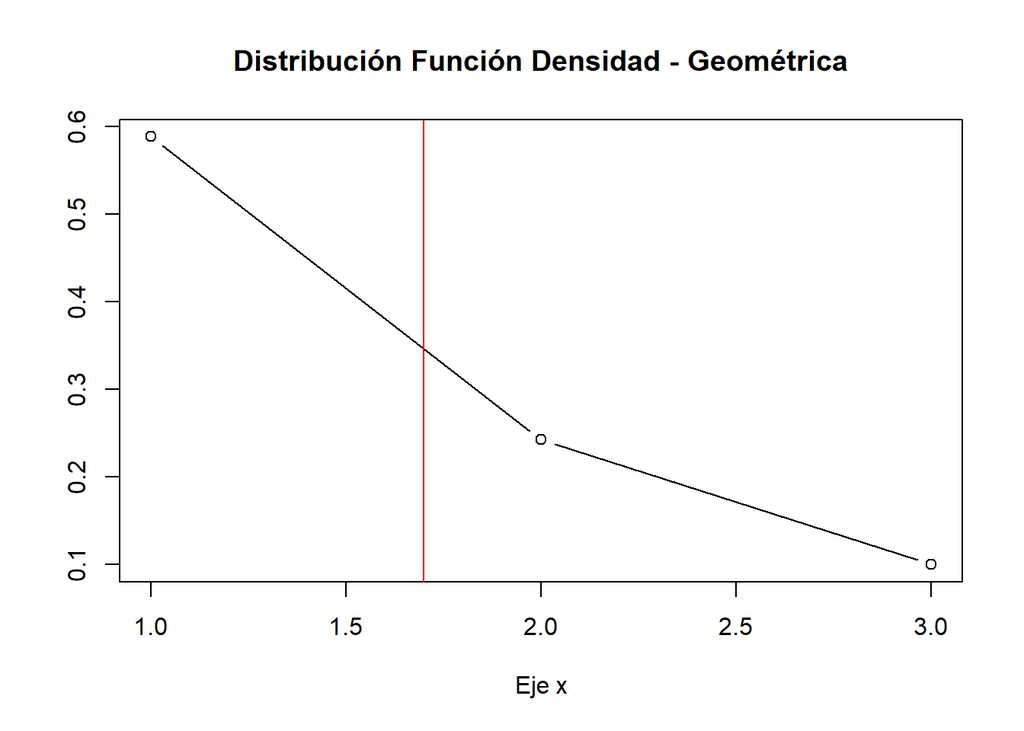

```r
# Al usar la función en R para este distribución. Tener en cuenta su ecuación,
# ya que la función considere 'x' y no 'x-1' como mencionan los textos.

# Grafiquemos
# Función Densidad
x = seq(1,3)
plot(x, y = dgeom(x-1, prob = 10/17),
     main = "Distribución Función Densidad - Geométrica",
     xlab = "Eje x",
     ylab = " ",
     type = "b")
abline(v = 1/(10/17), col = "red")
```

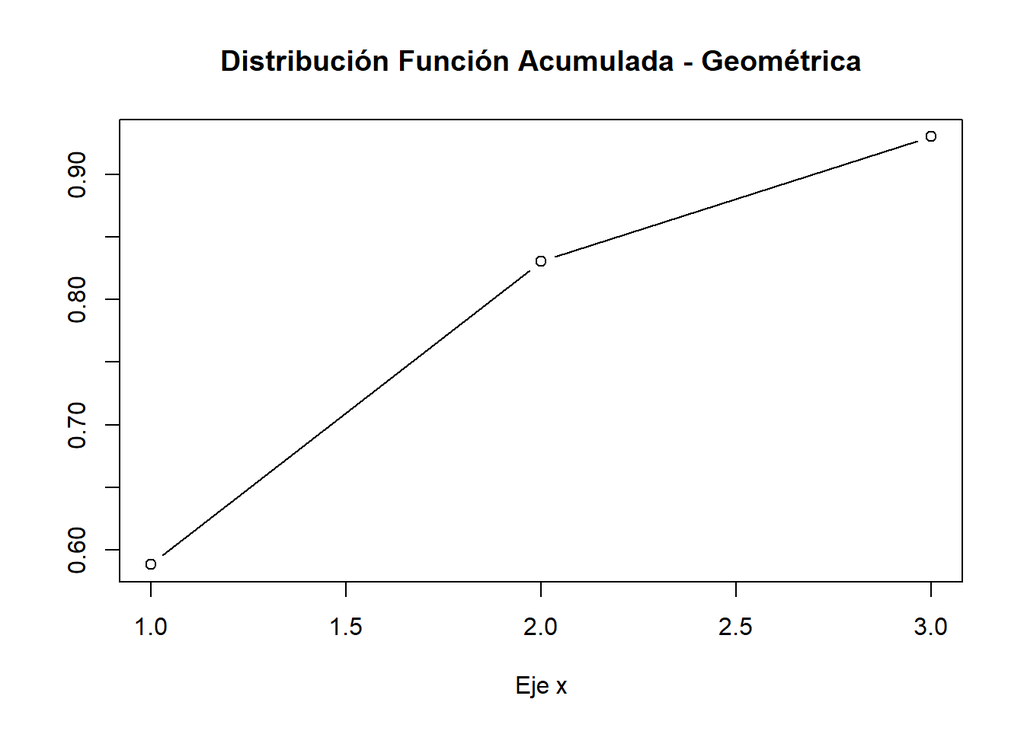

```r
# Función Acumulada
plot(x, pgeom(x-1, prob = 10/17),
     main = "Distribución Función Acumulada - Geométrica",
     xlab = "Eje x",
     ylab = " ",
     type = "b")
abline(h = 1, col = "red")
```

Dada una proporción del $58,82 \%$, se espera que al tercer intento de seleccionar a un alumno y que esta sea mujer es del $0,0997$ o $9,97 \%$.

### 1.19.4 Distribución Poisson

$$X \sim \mathbf{P}(\lambda)$$
Donde:

- $X:$ indica el número de éxitos al realizar un número indeterminado de veces el experimento de Bernoulli.
- $\lambda :$ indica el número de eventos que se dan en una unidad de tiempo geográfica.

$$\mathbf{P}(X=x)= \frac{\lambda^x}{x!} \cdot e^{-\lambda}$$

La Esperanza Matemática y su Varianza, son:  
$E(X)= \lambda$  
$V(X)= \lambda$

**Ejercicio**  
Se determina que el número de clientes que pueden ser atendidos por una ventanilla de una banco, es de $3 \frac{clientes}{minutos}$. Calcular, la probabilidad de que la ventanilla, según lo determinado atienda a $2 \frac{clientes}{minutos}$.

```r
dpois(x = 2, lambda = 3)
```

```
## [1] 0.2240418
```

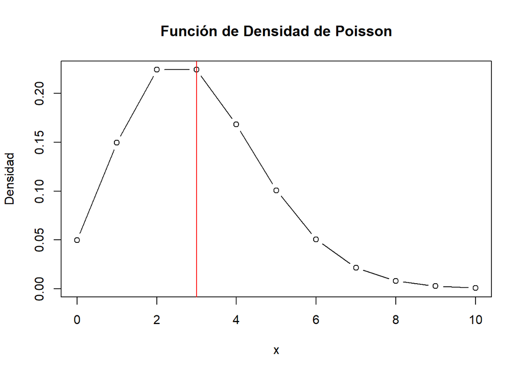

```r
# Grafiquemos
# Función Densidad
x <- 0:10  # Valores de x para los que se calculará la densidad de Poisson
lambda <- 3  # Parámetro lambda de la distribución de Poisson
# Calcula la densidad de Poisson para cada valor de x
densidad <- dpois(x, lambda)
# Grafica la función de densidad de Poisson
plot(x, densidad, type = "b", main = "Función de Densidad de Poisson", xlab = "x", ylab = "Densidad")
abline(v = lambda, col = "red")
```

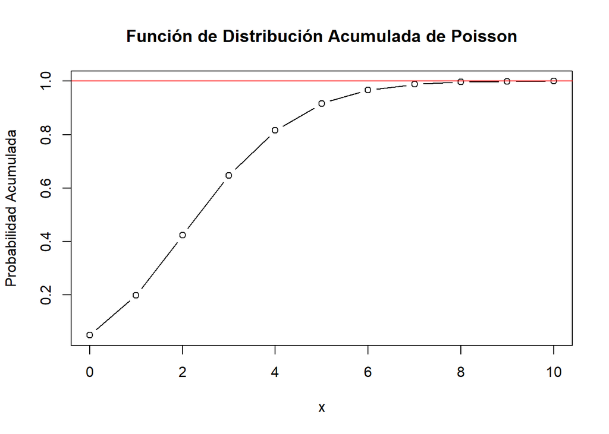

```r
# Función Acumulada
# Calcula la función de distribución acumulada de Poisson para cada valor de x
acumulada <- ppois(x, lambda)
# Grafica la función de distribución acumulada de Poisson
plot(x, acumulada, type = "b", main = "Función de Distribución Acumulada de Poisson", xlab = "x", ylab = "Probabilidad Acumulada")
abline(h=1, col = "red")
```

Del resultado, tenemos que el $22,40 \%$ la ventanilla a evaluar esté atendiendo a $2 \frac{clientes}{minutos}$.

### 1.19.5 Distribución Hipergeométrica

$$X \sim \mathbf{HG}(N,K,n)$$
Donde:

- $X:$ indica el número de elementos de la categoría o grupo de interés (a) seleccionados de entre los (n) escogidos.
- $N: N = a + b$

La expresión matemática de la Distribución Hipergeométrica,

$$\mathbf{P}(X=x)= \frac{\binom{a}{x} \binom{n}{n-x}}{\binom{N}{n}}$$

La Esperanza Matemática y su Varianza, son:  
$E(X)= \frac{n \cdot a}{N}$  
$V(X)= \frac{n \cdot a}{N} \cdot \frac{N-a}{N} \cdot \frac{N-n}{N-1}$

**Ejercicio**  
Calcular la probabilidad de tener 2 hombres de entre los 5 seleccionados. Teniendo en cuenta que $n=5$, el total de hombres es $7$ y de mujeres $10$.

```r
# Parámetros
n_hombres <- 7
n_mujeres <- 10
total_personas <- n_hombres + n_mujeres
n_seleccionados <- 5
x <- 2  # Número de hombres que queremos en la muestra

# Cálculo de la probabilidad hipergeométrica
probabilidad <- dhyper(x, n_hombres, n_mujeres, n_seleccionados)
probabilidad
```

```
## [1] 0.4072398
```

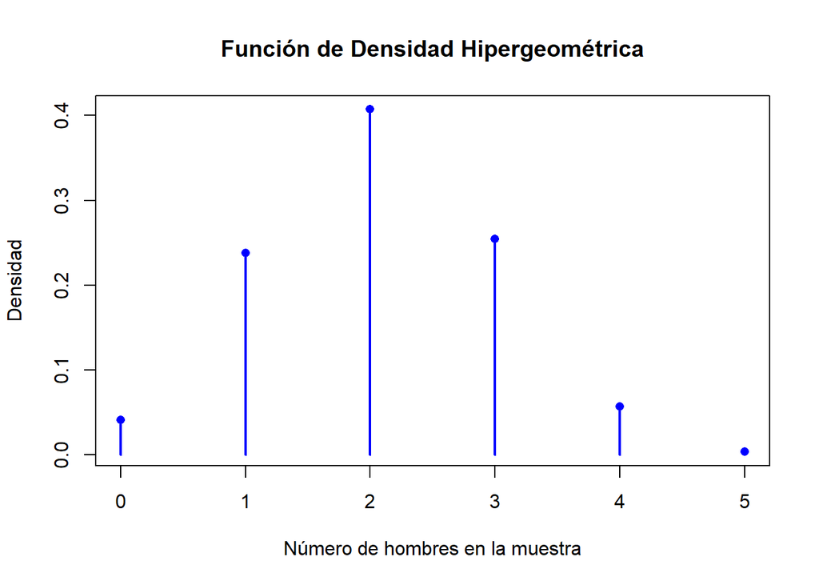

```r
# Gráficas para Dist. Hipergeométrica
# Valores posibles de x (número de hombres en la muestra)
x_vals <- 0:n_seleccionados

# Función de densidad
densidad <- dhyper(x_vals, n_hombres, n_mujeres, n_seleccionados)

# Graficar la función de densidad
plot(x_vals, densidad, type = "h", main = "Función de Densidad Hipergeométrica",
     xlab = "Número de hombres en la muestra", ylab = "Densidad",
     lwd = 2, col = "blue")
points(x_vals, densidad, pch = 16, col = "blue")
```

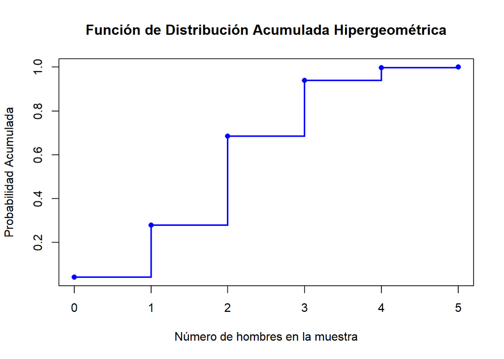

```r
# Función de distribución acumulada
acumulada <- phyper(x_vals, n_hombres, n_mujeres, n_seleccionados)

# Graficar la función de distribución acumulada
plot(x_vals, acumulada, type = "s", main = "Función de Distribución Acumulada Hipergeométrica",
     xlab = "Número de hombres en la muestra", ylab = "Probabilidad Acumulada",
     lwd = 2, col = "blue")
points(x_vals, acumulada, pch = 16, col = "blue")
```

## 1.20 Principales Distribuciones de Probabilidad con Variable Aleatoria Continua